# Most Harmful Weather Events Between 1950 and 2011

## Synopsis

In this report we aim to identify the most harmful severe weather events in the United States. We explore which types of weather events are most harmful to population health, as well as which types of events have the greatest economic impact. For our analysis, we use data from U.S. National Oceanic and Atmospheric Administration’s (NOAA) storm database (found [here](https://d396qusza40orc.cloudfront.net/repdata%2Fdata%2FStormData.csv.bz2), with corresponding documentation [here](https://d396qusza40orc.cloudfront.net/repdata%2Fpeer2_doc%2Fpd01016005curr.pdf)). The database tracks characteristics of major storms and weather events in the United States, including when and where they occur, as well as estimates of any fatalities, injuries, and property damage. The data we use for our analysis includes events from 1950 to November 2011. Based on the data we find the weather events that caused the most combined property and crop damage on average, the most fatalities on average, and the most injuries on average, as well as which weather events caused the most total combined property and crop damage, and the most total combined fatalities and injuries. We infer from this analysis which weather events have the greatest economic impact and are the most harmful to population health. All code involved in the analysis described in this paper can be found in the github repository found [here](https://github.com/eickemea/RepData_PeerAssessment2).

## Data Processing

### Reading in the Data

We break up the processing of the data for our analysis into three scripts. The first script, read_data.R, downloads the zip file containing the data to the current working directory if necessary, reads the data into R, and then returns a data frame containing the data (Due to the size of the data, this script might take a bit of time to run):

```r
# Download data to working directory if necessary
if(!file.exists("StormData.csv.bz2")){
      # Download zip file
      url <- "https://d396qusza40orc.cloudfront.net/repdata%2Fdata%2FStormData.csv.bz2"
      download.file(url, destfile = "StormData.csv.bz2")
}

data <- read.csv("StormData.csv.bz2")
data
```

### Reformatting and Consolidating Event Types

Taking a quick look at the levels of the *EVTYPE* variable, which indicates the type of weather event for each observation, we have the following:

```r
unique(data$EVTYPE)
```

```
##   [1] TORNADO                        TSTM WIND
##   [3] HAIL                           FREEZING RAIN
##   [5] SNOW                           ICE STORM/FLASH FLOOD
##   [7] SNOW/ICE                       WINTER STORM
##   [9] HURRICANE OPAL/HIGH WINDS      THUNDERSTORM WINDS
##  [11] RECORD COLD                    HURRICANE ERIN
##  [13] HURRICANE OPAL                 HEAVY RAIN
##  [15] LIGHTNING                      THUNDERSTORM WIND
##  [17] DENSE FOG                      RIP CURRENT
##  [19] THUNDERSTORM WINS              FLASH FLOOD
##  [21] FLASH FLOODING                 HIGH WINDS
##  [23] FUNNEL CLOUD                   TORNADO F0
##  [25] THUNDERSTORM WINDS LIGHTNING   THUNDERSTORM WINDS/HAIL
##  [27] HEAT                           WIND
##  [29] LIGHTING                       HEAVY RAINS
```

[output cut: 479 more lines]

The number of levels for the *EVTYPE* variable is a clear issue, as there are a total of 985 levels, whereas the documentation shows this variable having only 48 levels. A quick glance over the names of the different levels reveals at least one clear contributor to this discrepency: there are a number of levels that represent the same event but were made separate due to typos and case sensitivity. There are also levels that either don’t clearly fit into the event types in the documentation, or could fit into multiple categories.

The reformat_events.R script attempts to consolidate as many of the different levels present into the data frame into the event types from the documentation. The script also adds a few new categories not present in the documentation to account for as many of the observations that have levels that don’t fit into any of the event types from the documentation. Some of the inclusions in each category can be considered subjective, and a different manner of consolidation could yield different results in the later analysis. Any observations with event types that we could not consolidate are excluded from the data frame returned by the script. The number of observations excluded is relatively small, and the event types excluded appeared with small enough multiplicity each that meaningful conclusions would not have been able to be drawn about them anyway. This is not ideal, but it should not impact the results of our analysis.

First, the reformat_events.R script installs the **dplyr** package if necessary and loads the package into R:

```r
# Install dplyr package if necessary
if(!require(dplyr)){
      install.packages("dplyr")
}

# Load dplyr package
library(dplyr)
```

Next, the script loads the read_data.R script into R (the script must be in the current working directory) and reads in the data using the script:

```r
# Load the function that reads in the data. The script must be in working directory.
source('./read_data.R')

# Read in the data
data <- read_data()
```

Now, a new variable, *Event_Type*, is added to the data frame by converting the *EVTYPE* variable into a character variable:

```r
# Add a new variable, Event_Type, which condenses the factor variable EVTYPE
# into a smaller number of event types (i.e. multiple event types present in EVTYPE represent similar types of events
# or the same type of event, so we group all such events into a single event for the Event_Type variable)
data <- mutate(data, Event_Type = as.character(EVTYPE))
```

The script then attempts to consolidate as many of the events that appear in the the *Event_Type* variable into the event types present in the documentation, as well as a couple event types that are not present in the documentation, but were deemed necessary for the integrity of the later analysis. This is achieved through the use of regular expressions and the *grepl()* function:

```r
# Replace similar/same types of events in EVTYPE with a single event for the Event_Type variable
drought <- grepl("drought|dry|driest|record low rainfall", data$Event_Type, ignore.case = TRUE)
data$Event_Type[drought] <- "Drought"

lowtide <- grepl("astronomical low tide", data$Event_Type, ignore.case = TRUE)
data$Event_Type[lowtide] <- "Astronomical Low Tide"

avalanche <- grepl("avalanche|avalance", data$Event_Type, ignore.case = TRUE)
data$Event_Type[avalanche] <- "Avalanche"

blizzard <- grepl("blizzard", data$Event_Type, ignore.case = TRUE)
data$Event_Type[blizzard] <- "Blizzard"

coastal.flood <- grepl("coastal flood", data$Event_Type, ignore.case = TRUE)
data$Event_Type[coastal.flood] <- "Coastal Flood"

debris.flow <- grepl("debris flow", data$Event_Type, ignore.case = TRUE)
data$Event_Type[debris.flow] <- "Debris Flow"

fog <- grepl("fog", data$Event_Type, ignore.case = TRUE)
data$Event_Type[fog] <- "Fog"

dense.smoke <- grepl("dense smoke", data$Event_Type, ignore.case = TRUE)
data$Event_Type[dense.smoke] <- "Dense Smoke"

dust.devil <- grepl("dust devil|dustdevil|dust devel", data$Event_Type, ignore.case = TRUE)
data$Event_Type[dust.devil] <- "Dust Devil"

dust.storm <- grepl("dust storm|duststorm|blowing dust", data$Event_Type, ignore.case = TRUE)
data$Event_Type[dust.storm] <- "Dust Storm"

flash.flood <- grepl("flash flood|flash floood", data$Event_Type, ignore.case = TRUE)
data$Event_Type[flash.flood] <- "Flash Flood"

lakeshore.flood <- grepl("lakeshore flood", data$Event_Type, ignore.case = TRUE)
data$Event_Type[lakeshore.flood] <- "Lakeshore Flood"

flood <- grepl("flood", data$Event_Type, ignore.case = TRUE)
data$Event_Type[flood] <- "Flood"

funnel.cloud <- grepl("funnel cloud", data$Event_Type, ignore.case = TRUE)
data$Event_Type[funnel.cloud] <- "Funnel Cloud"

marine.hail <- grepl("marine hail", data$Event_Type, ignore.case = TRUE)
data$Event_Type[marine.hail] <- "Marine Hail"

hail <- grepl("hail", data$Event_Type, ignore.case = TRUE)
data$Event_Type[hail] <- "Hail"

rain <- grepl("rain", data$Event_Type, ignore.case = TRUE)
data$Event_Type[rain] <- "Rain"

heavy.snow <- grepl("heavy snow", data$Event_Type, ignore.case = TRUE)
data$Event_Type[heavy.snow] <- "Heavy Snow"

high.surf <- grepl("high surf", data$Event_Type, ignore.case = TRUE)
data$Event_Type[high.surf] <- "High Surf"

marine.high.wind <- grepl("marine high wind", data$Event_Type, ignore.case = TRUE)
data$Event_Type[marine.high.wind] <- "Marine High Wind"

high.wind <- grepl("high wind", data$Event_Type, ignore.case = TRUE)
data$Event_Type[high.wind] <- "High Wind"

hurricane <- grepl("hurricane|typhoon", data$Event_Type, ignore.case = TRUE)
data$Event_Type[hurricane] <- "Hurricane (Typhoon)"

ice.storm <- grepl("ice storm", data$Event_Type, ignore.case = TRUE)
data$Event_Type[ice.storm] <- "Ice Storm"

lake.effect.snow <- grepl("lake-effect snow|lake effect snow", data$Event_Type, ignore.case = TRUE)
data$Event_Type[lake.effect.snow] <- "Lake-Effect Snow"

lightning <- grepl("lightning|lighting", data$Event_Type, ignore.case = TRUE)
data$Event_Type[lightning] <- "Lightning"

marine.strong.wind <- grepl("marine strong wind", data$Event_Type, ignore.case = TRUE)
data$Event_Type[marine.strong.wind] <- "Marine Strong Wind"

marine.thunderstorm.wind <- grepl("marine thunderstorm wind", data$Event_Type, ignore.case = TRUE)
data$Event_Type[marine.thunderstorm.wind] <- "Marine Thunderstorm Wind"

rip.current <- grepl("rip current", data$Event_Type, ignore.case = TRUE)
data$Event_Type[rip.current] <- "Rip Current"

seiche <- grepl("seiche", data$Event_Type, ignore.case = TRUE)
data$Event_Type[seiche] <- "Seiche"

sleet <- grepl("sleet", data$Event_Type, ignore.case = TRUE)
data$Event_Type[sleet] <- "Sleet"

storm.surge.tide <- grepl("storm surge|tide", data$Event_Type, ignore.case = TRUE)
data$Event_Type[storm.surge.tide] <- "Storm Surge/Tide"

strong.wind <- grepl("strong wind", data$Event_Type, ignore.case = TRUE)
data$Event_Type[strong.wind] <- "Strong Wind"

thunderstorm.wind <- grepl("thunderstorm wind|thundestorm|thunderstorm|thunderstrom|thundeerstorm|thundertsorm|
                        thunderestorm|tunderstorm",data$Event_Type, ignore.case = TRUE)
data$Event_Type[thunderstorm.wind] <- "Thunderstorm"

tornado <- grepl("tornado|torndao", data$Event_Type, ignore.case = TRUE)
data$Event_Type[tornado] <- "Tornado"

tropical.depression <- grepl("tropical depression", data$Event_Type, ignore.case = TRUE)
data$Event_Type[tropical.depression] <- "Tropical Depression"

tropical.storm <- grepl("tropical storm", data$Event_Type, ignore.case = TRUE)
data$Event_Type[tropical.storm] <- "Tropical Storm"

tsunami <- grepl("tsunami", data$Event_Type, ignore.case = TRUE)
data$Event_Type[tsunami] <- "Tsunami"

volcanic <- grepl("volcanic", data$Event_Type, ignore.case = TRUE)
data$Event_Type[volcanic] <- "Volcanic Activity"

waterspout <- grepl("waterspout|water spout", data$Event_Type, ignore.case = TRUE)
data$Event_Type[waterspout] <- "Waterspout"

wildfire <- grepl("wildfire|wild fire|fire", data$Event_Type, ignore.case = TRUE)
data$Event_Type[wildfire] <- "Wildfire"

winter.storm <- grepl("winter storm|ice storm", data$Event_Type, ignore.case = TRUE)
data$Event_Type[winter.storm] <- "Winter Storm"

winter.weather <- grepl("winter weather|snow|freezing drizzle|freezing rain|wintry mix|ice pellets|winter mix|wintery mix",
                        data$Event_Type, ignore.case = TRUE)
data$Event_Type[winter.weather] <- "Winter Weather"

heat <- grepl("heat|record high|warm|hot|high temperature", data$Event_Type, ignore.case = TRUE)
data$Event_Type[heat] <- "Heat"

cold.windchill <- grepl("cold|windchill|low temperature|wind chill", data$Event_Type, ignore.case = TRUE)
data$Event_Type[cold.windchill] <- "Cold/Wind Chill"

frost.freeze <- grepl("frost|freeze|ice|icy", data$Event_Type, ignore.case = TRUE)
data$Event_Type[frost.freeze] <- "Frost/Freeze"

wind <- grepl("wind", data$Event_Type, ignore.case = TRUE)
data$Event_Type[wind] <- "Wind"

mudslide.landslide <- grepl("mudslide|mud slide|landslide|land slide|mud/rock slide", data$Event_Type, ignore.case = TRUE)
data$Event_Type[mudslide.landslide] <- "Mudslide/Landslide"

wetness <- grepl("wet", data$Event_Type, ignore.case = TRUE)
data$Event_Type[wetness] <- "Wetness"
```

Finally, the script creates a new data frame by extracting all observations that fall into the consolidated event categories and returns the new data frame:

```r
#Extract only the observations that represent events from these new, condensed event types
events <- c("Drought", "Astronomical Low Tide", "Avalanche", "Blizzard", "Coastal Flood", "Debris Flow", "Fog",
            "Dense Smoke", "Dust Devil", "Dust Storm", "Flash Flood", "Lakeshore Flood", "Flood", "Funnel Cloud",
            "Marine Hail", "Hail", "Rain", "Heavy Snow", "High Surf", "Marine High Wind", "High Wind",
            "Hurricane (Typhoon)", "Ice Storm", "Lake-Effect Snow", "Lightning", "Marine Strong Wind",
            "Marine Thunderstorm Wind", "Rip Current", "Seiche", "Sleet", "Storm Surge/Tide", "Strong Wind",
            "Thunderstorm", "Tornado", "Tropical Depression", "Tropical Storm", "Tsunami", "Volcanic Activity",
            "Waterspout", "Wildfire", "Winter Storm", "Winter Weather", "Heat", "Cold/Wind Chill", "Frost/Freeze",
            "Wind", "Mudslide/Landslide", "Wetness")
data2 <- filter(data, Event_Type %in% events)
```

### Adding the True Crop and Property Damage Values

Another issue with the data that we must address for our analysis is that the true values for crop damage and property damage are split into two variable each: *PROPDMG* and *PROPDMGEXP* for property damage, and *CROPDMG* and *CROPDMGEXP* for crop damage. The variables *PROPDMGEXP* and *CROPDMGEXP* are modifiers that when multiplied with corresponding observations for the *PROPDMG* and *CROPDMG* variables, yield the true property and crop damage for an observation, respectively. If we look at the possible values for *PROPDMGEXP* and *CROPDMGEXP* variables, we can see that their values are symbols representing a numerical modifier:

```r
unique(data2$PROPDMGEXP)
```

```
##  [1] K M   B m + 0 5 6 ? 4 2 3 h 7 H - 1 8
## Levels:  - ? + 0 1 2 3 4 5 6 7 8 B h H K m M
```

```r
unique(data2$CROPDMGEXP)
```

```
## [1]   M K m B ? 0 k 2
## Levels:  ? 0 2 B k K m M
```

Unfortunately, the documentation does not provide an explanation for what numerical values these symbols represent. To handle this issue, we refer to an analysis by Soesilo Wijono which matches each value of *PROPDMGEXP* and *CROPDMGEXP* with its appropriate numerical value. The analysis can be found [here](https://github.com/flyingdisc/RepData_PeerAssessment2/blob/master/how-to-handle-PROPDMGEXP.md).

The process_data.R script adds to the data the variables *PropDamage* and *CropDamage*, which contain the true values for the property damage and crop damage of each observation, respectively. First, the script loads the reformat_events.R script into R (the script must be in the current working directory) and then uses the script to load in the data with consolidated event types:

```r
# Load in the function that adds a new, condensed event type variable to the data and extracts relevant observations
source("./reformat_events.R")

# Load in the extracted data
data <- reformat_events()
```

Next, the script adds the variables *PropExp* and *CropExp*, which contain the true numerical modifiers for the *PROPDMG* and *CROPDMG* variables, respectively, to the data frame:

```r
# Add a new variable, PropExp, which represents the coefficient for the variable PROPDMG, indicated by
# the factor variable, PROPDMGEXP.
PropExp = c(1000, 1000000, 0, 1000000000, 1000000, 1, 10, 10, 10, 0, 10, 10, 10, 100, 10, 100, 0, 10, 10)
propmatch <- data.frame(PROPDMGEXP = unique(data$PROPDMGEXP), PropExp = PropExp)
data <- merge(data, propmatch)

# Add a new variable, CropExp, which represents the coefficient for the variable, CROPDMG, indicated by
# the factor variable, CROPDMGEXP
CropExp <- c(0, 1000, 1000000, 10, 1000000000, 0, 10, 1000, 1000000)
cropmatch <- data.frame(CROPDMGEXP = unique(data$CROPDMGEXP), CropExp = CropExp)
data <- merge(data, cropmatch)
```

Finally, the variable *PropDamage* and *CropDamage* are added to the data frame by multiplying the corresponding values of the variables *PROPDMG* and *PropExp* together for *PropDamage* and the corresponding values of *CROPDMG* and *CropExp* for *CropDamage*. The data frame is returned:

```r
data <- mutate(data, CropDamage = CROPDMG*CropExp, PropDamage = PROPDMG*PropExp)
```

## Results

### Event Types with Greatest Economic Consequence

To determine which event types have the greatest economic consequences, we analyze the *PropDamage* and *CropDamage* variables, which measure the property and crop damage of weather events, respectively. We analyze the economic impact of the various event types in two ways: which event types produce the greatest combined property and crop damage on average, and which event type produce the greatest total combined property and crop damage over time. From the former we can infer which event types have the greatest economic consequence stemming from a single event. From the latter we can infer which event types will have the greatest economic impact over the course of a stretch of time, which is influence by both the amount of economic damage caused by a single event as well as the frequency with which any given event type occurs.

The econ_analysis.R script produces a panel plot consisting of two bar plot which display the damage caused by the top five event types that caused the most combined property and crop damage on average, as well as the damage caused by the top five event types that caused the most combined property and crop damage in total. First, the script loads the process_data.R script into R, installs the **ggplot2** and **gridExtra** packages if necessary, and loads the packages into R:

```r
# Load the function that reads in the data. The script must be in working directory.
source('./process_data.R')

# Install ggplot2 package if necessary
if(!require(ggplot2)){
      install.packages("ggplot2")
}

# Install gridExtra package if necessary
if(!require(gridExtra)){
      install.packages("gridExtra")
}

# Load ggplot2 and gridExtra packages into R
library(ggplot2)
library(gridExtra)
```

Next the script reads in the processed data into R using the process_data.R script. The data is then grouped by the *Event_Type* variable, and using the grouped data a new data frame is created containing the average and total combined crop and property damage for each event type:

```r
# Read in the processed data
data <- process_data()

# Group the data by Event_Type
grouped <- group_by(data, Event_Type)

# Create a new data frame containing the average of the sum of the crop and property damage for each event type and
# the total combined crop and property damage for each event
damage <- summarize(grouped, AvgDamage = mean(CropDamage + PropDamage), totalDamage = sum(CropDamage+PropDamage))
```

Using this new data frame, the top five events that cause the most combined crop and property damage on average are extracted and a bar plot displaying the average damage for each of these events is created (but, not yet printed):

```r
# Create a new data frame by extracting the top 5 event types that cause the most average damage
topFiveAvgDmg <- arrange(damage, desc(AvgDamage))[1:5,]

# Create a bar plot of the average damage caused by the extracted 5 event types
plot1 <- ggplot(topFiveAvgDmg, aes(Event_Type, AvgDamage)) + geom_bar(stat = "identity") +
      xlab("Event Type") + ylab("Average Damage") +
      ggtitle("Average Crop and Property Damage by Weather Events") +
      theme(plot.title = element_text(hjust = 0.5))
```

Likewise, the top five events that cause the most total combined crop and proerty damage are extracted and a bar plot displaying the total damage for each of of these events is created (again, not yet printed):

```r
# Create a new data frame by extracting the top 5 event types that cause the most total damage
topFiveDmg <- arrange(damage, desc(totalDamage))[1:5,]

# Create a bar plot of the total damage caused by the extracted 5 event types
plot2 <- ggplot(topFiveDmg, aes(Event_Type, totalDamage)) + geom_bar(stat = "identity") +
      xlab("Event Type") + ylab("Total Damage") +
      ggtitle("Total Crop and Property Damage by Weather Events") +
      theme(plot.title = element_text(hjust = 0.5))
```

Finally, a panel plot is printed consisting of the two plots we have previously created. The top plot displays the top five event types that cause the most combined crop and property damage on average on the horizontal-axis and their associated average damage on the vertical-axis. The bottom plot displays the top five events that cause the most total combined crop and property damage on the horizontal-axis and their associated total damage on the vertical-axis:

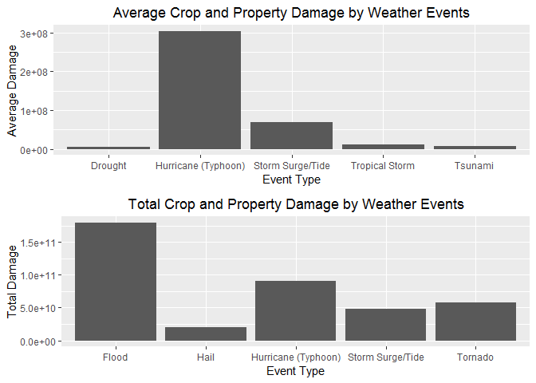

```r
grid.arrange(plot1, plot2, nrow=2)
```

We can see from the top plot that hurricanes/typhoons were the weather event that caused the most property and crop damage on average, while we can see from the bottom plot that floods were the weather event that caused the most total property and crop damage. Given that property and crop damage are the measures of a weather event’s economic impact present in the data provided, we can infer that on a single-event basis hurricanes and typhoons have the greatest economic impact among the weather events analyzed, while floods have the greatest economic impact in total over time among the weather events analyzed.

### Event Type Most Harmful to Population Health

To determine which event types are most harmful to population health, we analyze the *FATALITIES* and *INJURIES* variables, which measure the number of fatalities and injuries resulting from weather events, respectively. We analyze how harmful the various event types are to population health in three ways: which event types cause the most fatalities on average, the most injuries on average, and the most combined fatalities and injuries in total. From the first two measures we can infer which event types are most harmful to population health on a single event basis. From the third measure we can infer which event types are most harmful to population health over the course of a stretch of time, which, again, is influenced by the amount of harm caused by a single event as well as the frequency with which any given event type occurs.

The health_analysis.R script takes a logical argument, *total*, and prints out different bar plots based on the value of this argument. First, the script loads the process_data.R script into R, installs the **ggplot2** and **gridExtra** packages if necessary, and loads the packages into R:

```r
# Load the function that reads in the data. The script must be in working directory.
source('./process_data.R')

# Install ggplot2 package if necessary
if(!require(ggplot2)){
      install.packages("ggplot2")
}

# Install gridExtra package if necessary
if(!require(gridExtra)){
      install.packages("gridExtra")
}

# Load ggplot2 and gridExtra packages into R
library(ggplot2)
library(gridExtra)
```

Next, the script reads the processed data into R using the process_data.R script, groups the data by the *Event_Type* variable, and uses the grouped data to produce a new data frame containing the average and total number of fatalities, as well as the average and total number of injuries, for each event type:

```r
# Read in the processed data
data <- process_data()

# Group the data by Event_Type
grouped <- group_by(data, Event_Type)

# Create a new data frame containing the average number of fatalities and average number of injuries for each
# event type, as well as the total number of fatalities and injuries for each event type
damage <- summarize(grouped, AvgFatalities = mean(FATALITIES), AvgInjuries = mean(INJURIES),
                  totFatalities = sum(FATALITIES), totInjuries = sum(INJURIES))
```

Now, three separate data frames are created that will be used in generating bar plots. These data frames are produced by extracting from the new data frame the top five events that caused the most average fatalities, average injuries, and total combined fatalities and injuries, respectively:

```r
# Create a new data frame by extracting the top 5 event types that cause the most average fatalities
topFiveAvgFat <- arrange(damage, desc(AvgFatalities))[1:5,]

# Create a new data frame by extracting the top 5 event types that cause the most average injuries
topFiveAvgInj <- arrange(damage, desc(AvgInjuries))[1:5,]

# Create a new data frame by extracting the top 5 event types that cause the most total combined injuries and fatalities
topFiveTot <- arrange(damage, desc(totFatalities + totInjuries))[1:5,]
```

Finally, bar plots are generated based on whether the argument *total* was set to TRUE or FALSE:

```r
if(!total){
      # Create a bar plot of the average fatalities for the top 5 events that cause the most fatalities on average
      plot1 <- ggplot(topFiveAvgFat, aes(Event_Type, AvgFatalities)) + geom_bar(stat = "identity") +
            xlab("Event Type") + ylab("Average Fatalities") +
            ggtitle("Average Fatalities by Weather Events") +
            theme(plot.title = element_text(hjust = 0.5))

      # Create a bar plot of the averge injuries for the top 5 events that cause the most injuries on average
      plot2 <- ggplot(topFiveAvgInj, aes(Event_Type, AvgInjuries)) + geom_bar(stat = "identity") +
            xlab("Event Type") + ylab("Average Injuries") +
            ggtitle("Average Injuries by Weather Events") +
            theme(plot.title = element_text(hjust = 0.5))

      # Print a panel plot comprised of the two plots created above
      grid.arrange(plot1, plot2, nrow = 2)
}else{
      # Create a data frame that will allow us to create a bar plot of the total combined fatalities and injuries
      # for the top 5 events that cause the most total combined fatalities of injuries, with the bars colored to
      # indicate how many total fatalities and injuries occurred for each event type
      values <- c(topFiveTot$totFatalities, topFiveTot$totInjuries)
      events <- rep(topFiveTot$Event_Type, 2)
      type <- c(rep("Fatalities", 5), rep("Injuries", 5))
      plotData <- data.frame(events, values)

      # Create the bar plot
      plot1 <- ggplot(plotData, aes(events, values)) + geom_bar(stat = "identity", aes(fill = type)) +
            xlab("Event Type") + ylab("Total Fatalities and Injuries") +
            ggtitle("Total Fatalities and Injuries by Weather Events") +
            theme(plot.title = element_text(hjust = 0.5))

      print(plot1)
}
```

If the *total* argument is set to FALSE, then the script will generate a panel plot consisting of two bar plots. The top plot displays the top five event types that caused the most fatalities on average on the horizontal-axis and their associated average number of fatalities on the vertical-axis. The bottom plot displays the top five event types that caused the most injuries on average on the horizontal-axis and their associated average number of injuries on the vertical-axis:

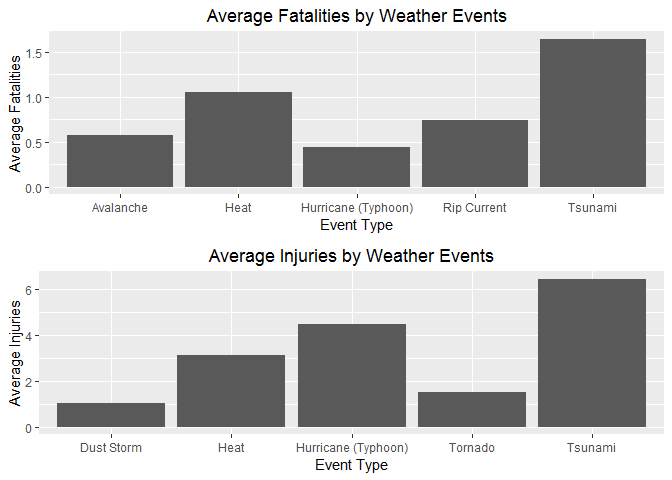

If the *total* argument is set to TRUE, then the script will generate a single bar plot that displays the top five event types that caused the most combined fatalities and injuries in total on the horizontal-axis and their associated total combined fatalities and injuries on the vertical-axis. The bars in the plot are colored to indicate how much injuries and fatalities contributed to the total for each event type:

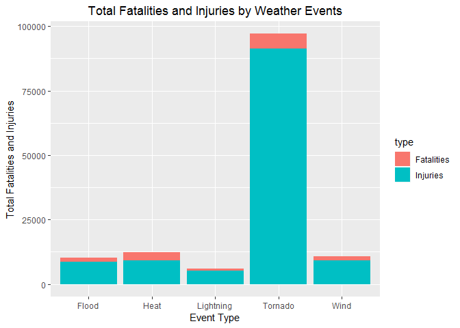

From the first figure we can see tsunamis were the weather event that caused both the most fatalities and injuries on average, while we can see from the second figure that tornados were the weather event that caused the most combined fatalities and injuries in total. Given that fatalities and injuries are the measures of a weather event’s harm to population health present in the data provided, we can infer that on a single-event basis tsunamis are the most harmful weather events to population health among those analyzed, while tornados are the most harmful to population health in total over time among the weather events analyzed.